# High-Dimensional Data Clustering with HDDC

Author

Andrew Kerr

# Introduction

Clustering high-dimensional data presents unique challenges due to the “curse of dimensionality.” Traditional clustering methods, like K-Means, can fail because high-dimensional data often lie in lower-dimensional subspaces. This presentation introduces the *High-Dimensional Data Clustering (HDDC)* method, which improves clustering by integrating Gaussian Mixture Models (GMMs) with subspace modeling.

## Motivation

- In many applications (e.g., image analysis, genomics), data points exist in hidden low-dimensional subspaces.
- Standard clustering methods fail to capture this structure because they give equal weight to all dimensions, however not all dimensions have the same importance.
- HDDC models each cluster within its intrinsic subspace, improving efficiency and accuracy.

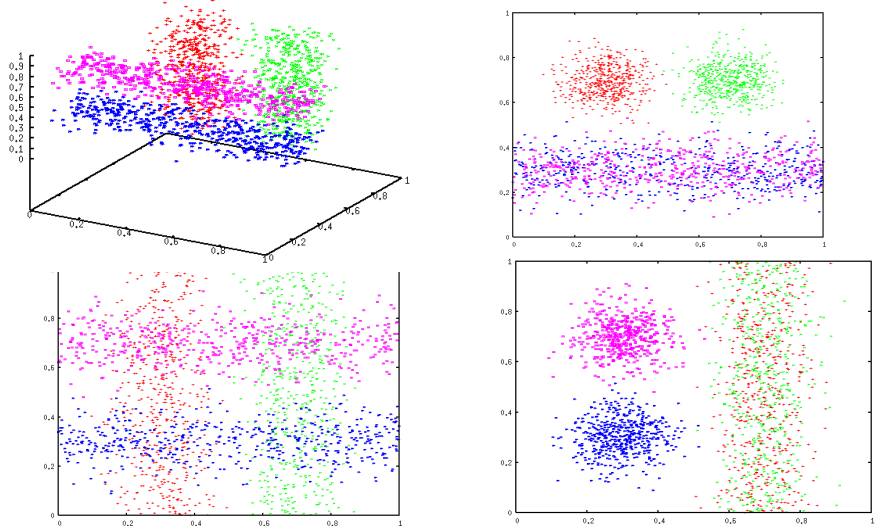

# Background Concepts

## Principal Component Analysis (PCA)

- PCA reduces dimensionality by finding directions (principal components) that maximize variance.
- HDDC extends this idea by estimating class-specific subspaces, allowing different clusters to exist in different lower-dimensional subspaces.

## Gaussian Mixture Models (GMMs)

- GMMs assume data come from a mixture of Gaussian distributions.
- Each cluster is modeled as a Gaussian distribution with parameters: mean ($\mu$), covariance ($\Sigma$), and mixing proportion ($\pi$).

## Expectation-Maximization (EM) Algorithm

- An iterative method to estimate GMM parameters.
- Alternates between:
  1. **Expectation (E-step):** Compute probabilities of each point belonging to a cluster.
  2. **Maximization (M-step):** Update parameters to maximize likelihood.

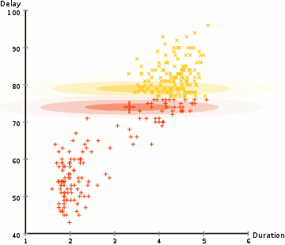

  EM Algorithm: Iterative parameter estimation

# The HDDC Model

HDDC enhances GMMs by modeling each cluster in its own subspace:

1. Each cluster exists in a lower-dimensional space (estimated using PCA-like methods).
2. Covariance matrices are regularized to prevent overfitting.
3. The Bayesian Information Criterion (BIC) is used to select the best model.

### HDDC Steps

1. **Estimate subspace for each cluster** using eigenvalue decomposition.
2. **Determine intrinsic dimension** of each cluster using the Scree test, which looks for an “elbow” in the eigenvalue spectrum to determine where the dimensionality significantly decreases.
3. **Fit Gaussian distributions** in the estimated subspaces.
4. **Classify points** using posterior probabilities.

# Model Variants in HDDC

HDDC allows for different assumptions about the structure of covariance matrices, leading to three main model variants:

### Free Orientation Model

- Each cluster has its own unique orientation, meaning that the covariance matrices have different eigenvector orientations across clusters.
- This model provides the most flexibility but requires estimating more parameters, which may lead to overfitting in small datasets.

### Common Orientation Model

- All clusters share the same orientation, meaning their covariance matrices have the same eigenvectors but different eigenvalues.
- This reduces the number of parameters to estimate while still allowing for different variances within each cluster.
- It assumes that clusters lie in aligned subspaces rather than completely independent ones.

### Common Covariance Matrix Model

- All clusters share the same covariance matrix, meaning both the eigenvectors and eigenvalues are common across clusters.
- This model is the most constrained and assumes that clusters have similar spread and shape.
- It is computationally efficient and avoids overfitting but may not work well when clusters have significantly different structures.

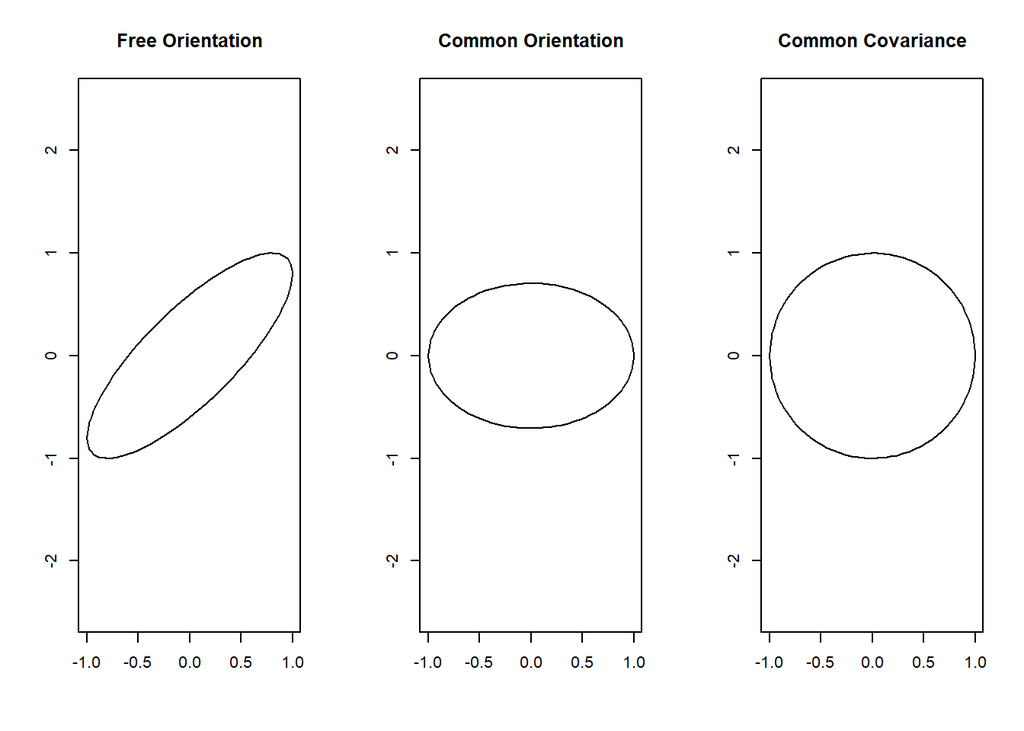

  HDDC Model Variants

# Example: HDDC v. K-Means

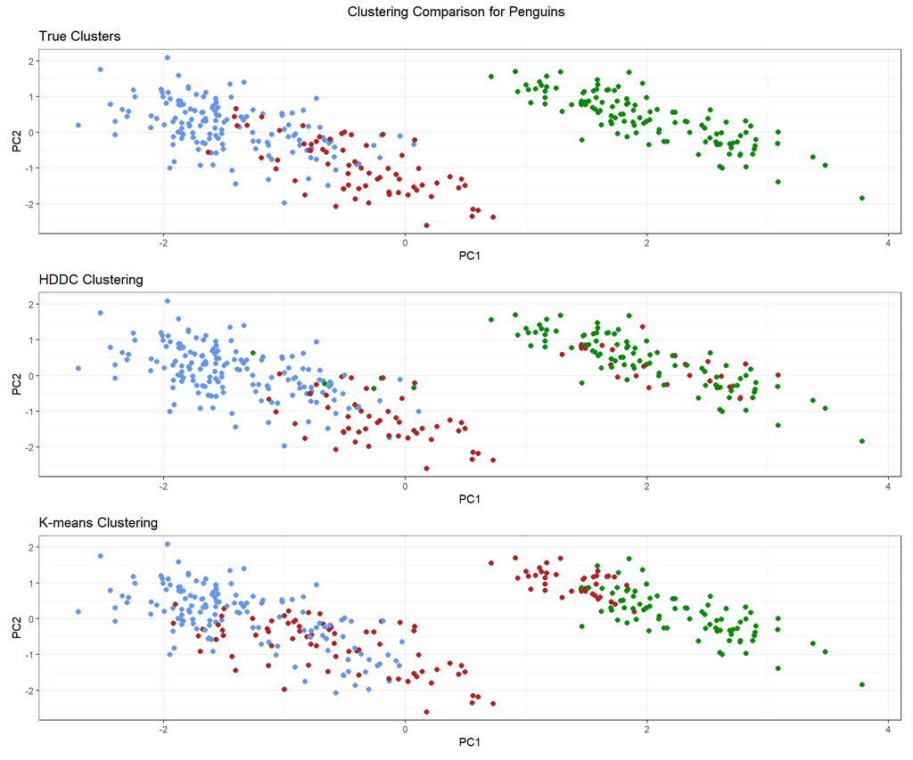

```
HDDC ARI: 0.6744083
K-Means ARI: 0.3126346
```

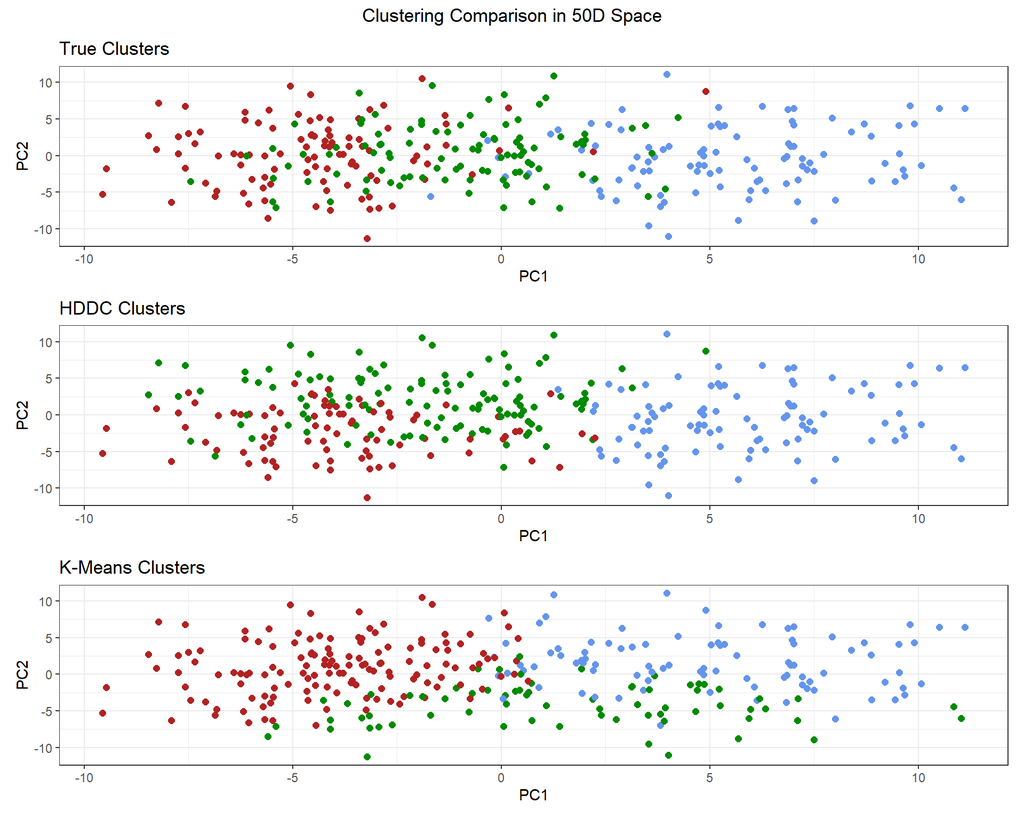

```
HDDC ARI: 0.4075991
K-Means ARI: 0.2829519
```

# Discussion Questions

1. **What are potential limitations of HDDC?**
2. **How HDDC performs when the number of dimensions is comparable to the number of observations (**$n \approx p$**)?**
3. **How does HDDC scale to very large datasets (e.g., millions of observations)?**
4. **Can we check whether HDDC is appropriate for a given dataset?**
5. **The paper presents experiments on both artificial and real datasets. What are some advantages of testing clustering algorithms on artificial datasets before applying them to real-world data?**
6. **What real-world applications could HDDC be applied to (outside of those in the paper)?**